# Graphics in R

## Stacked bar plot

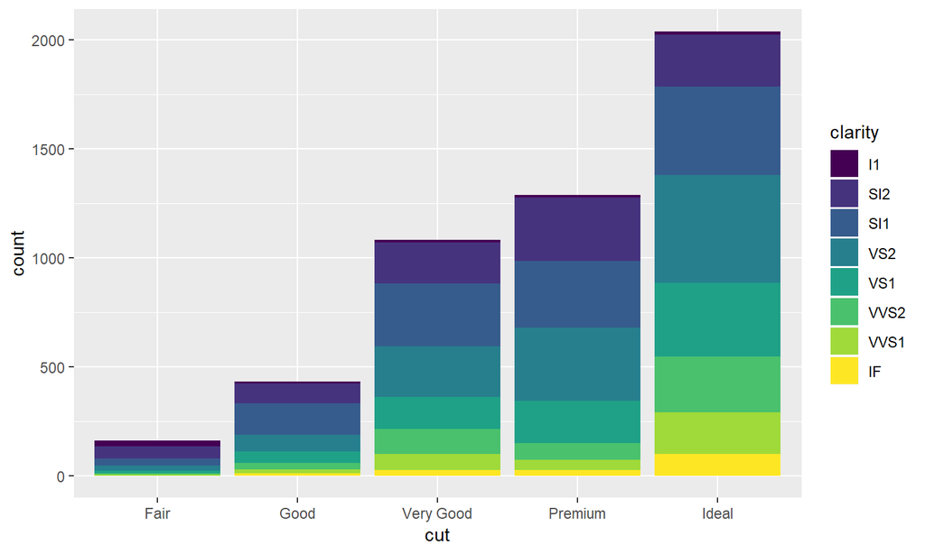

## Dodged bar plot

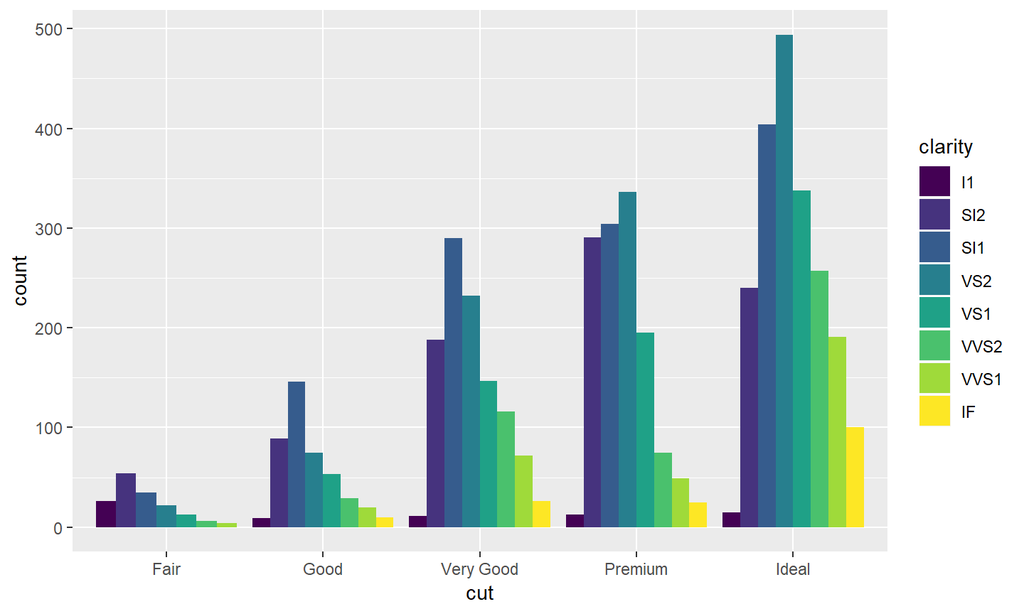

## Filled bar plot

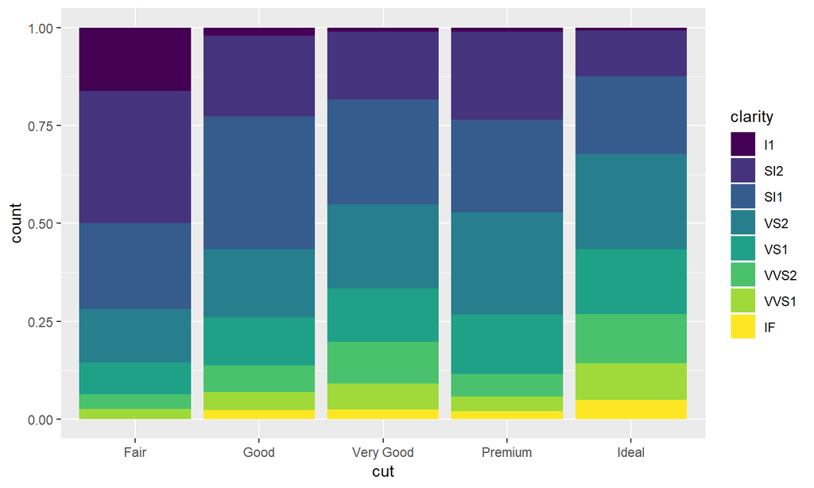

## Scales

- scales determine how the date are mapped to the asthetics (e.g. which value takes which color)
- scales are defined by functions of the form `scale_aestheticname_scalename()`

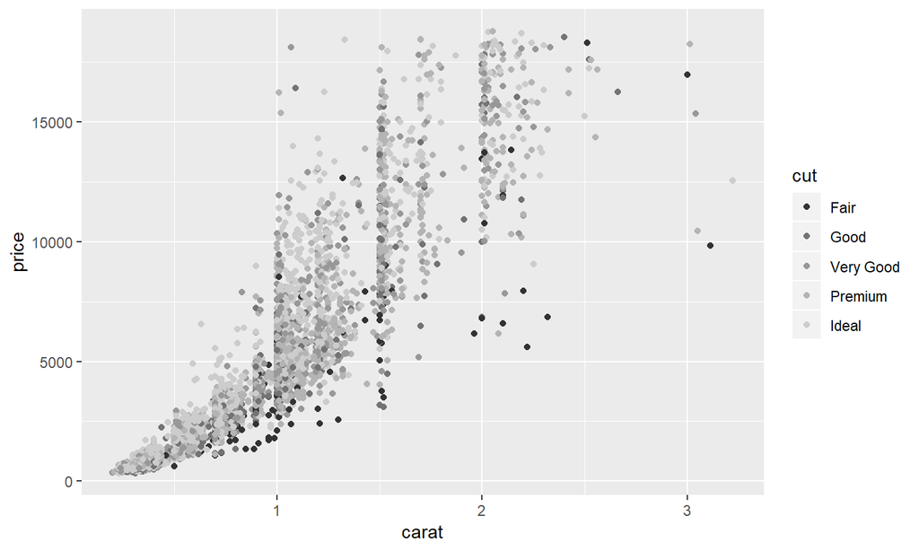

```r
ggplot(diamonds, aes(carat, price, color = cut)) + geom_point() + scale_color_grey()
```

## Scales

- you can also use your own scales

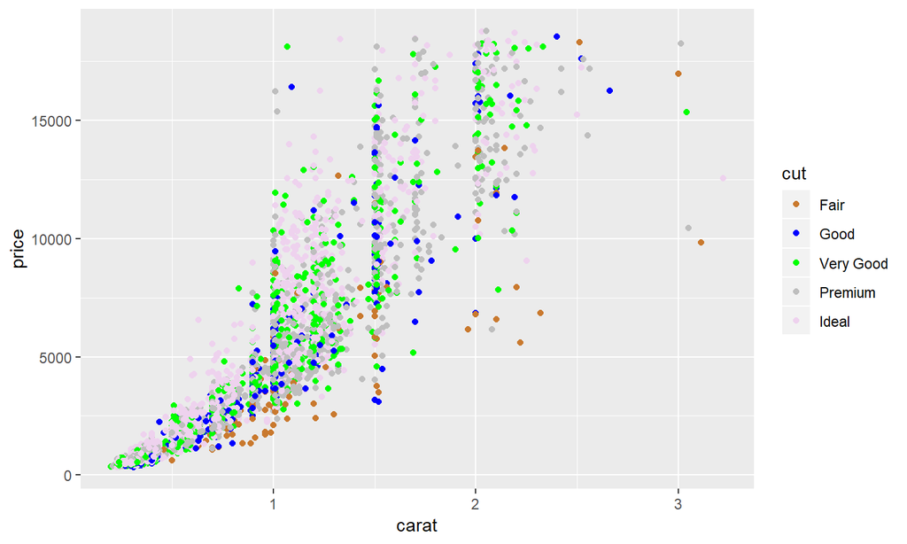

```r
ggplot(diamonds, aes(carat, price, color = cut)) +
  geom_point() +
  scale_color_manual(values = c("#c9792e", "blue", "green", "gray", "thistle2"))
```

## Titles and labels

With the function `labs()` you can - add a title and a subtible - add a caption - add a tag - change the axis lables - change the legend tilte

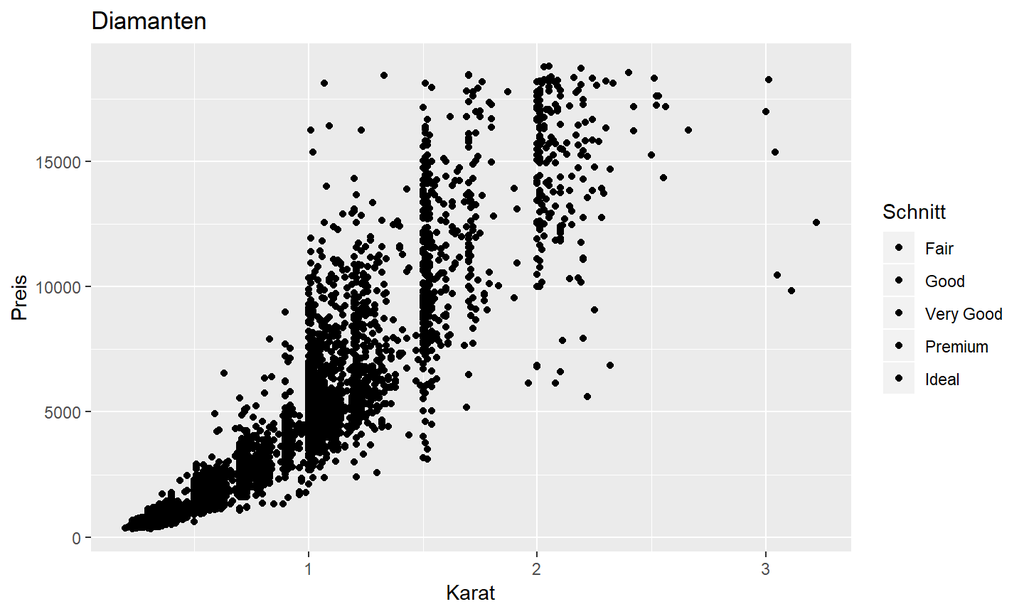

```r
ggplot(diamonds, aes(x = carat, y = price, fill = cut)) +
  geom_point() +
  labs(title = "Diamanten", x = "Karat", y = "Preis", fill = "Schnitt")
```

## Titles and labels

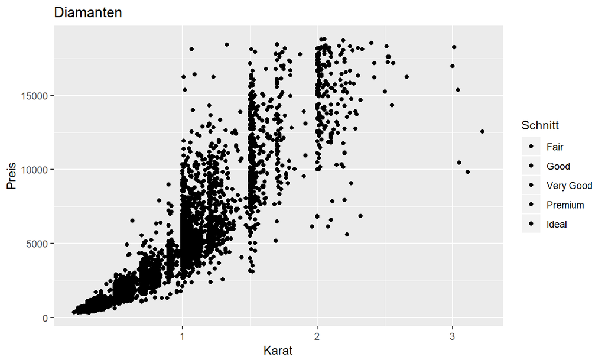

## Themes

Themes control the appearance of the plot

- fontype and fontsize
- background
- ticks marks and labels
- grid lines
- …

There are many predefined themes, however, if you like you can define all by yourself

## Themes

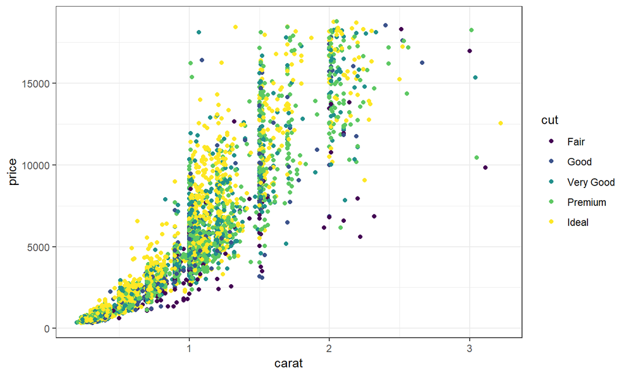